# AID - Trabajo Final

## Evolución de albums en el tiempo

Hemos visto anteriormente qué, con el correr del tiempo, la duración de los discos ha crecido. Este fenómeno podría deberse a que hubiera un aumento en la duración de las canciones o un aumento en la cantidad de canciones. Como puede verse en los siguientes gráficos, la duración media de las canciones por disco pareciera mantenerse estable a lo largo del tiempo, mientras que la cantidad de canciones pareciera crecer paulatinamente y ser la responsable del aumento en la duración de los discos.

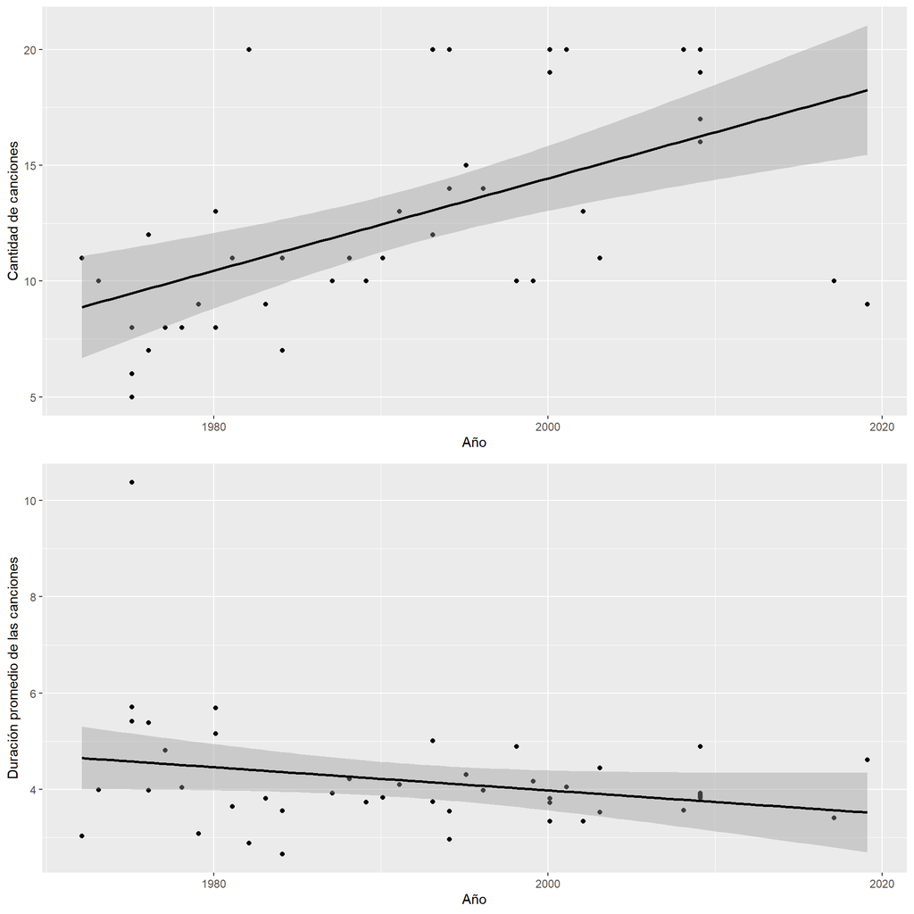

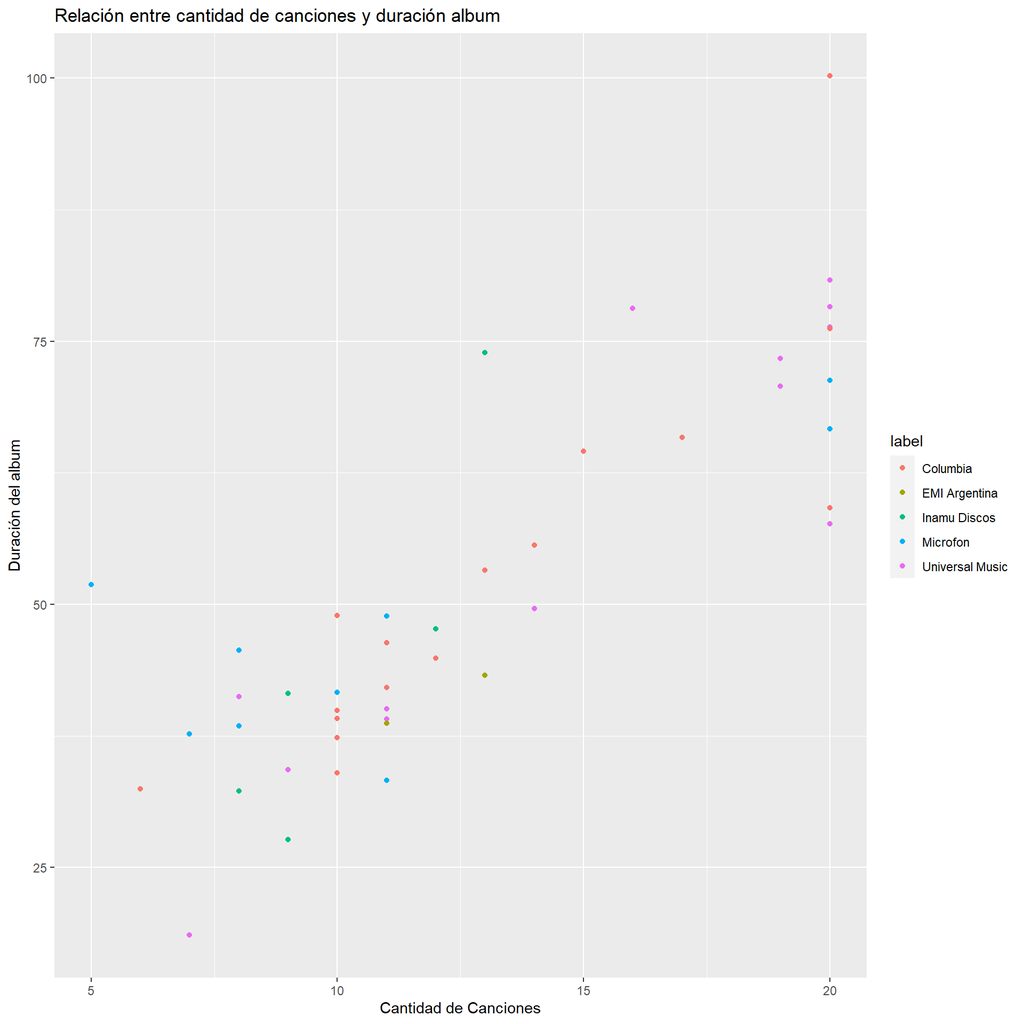

A continuación se muestra una animación con la evolución del largo de disco por año.

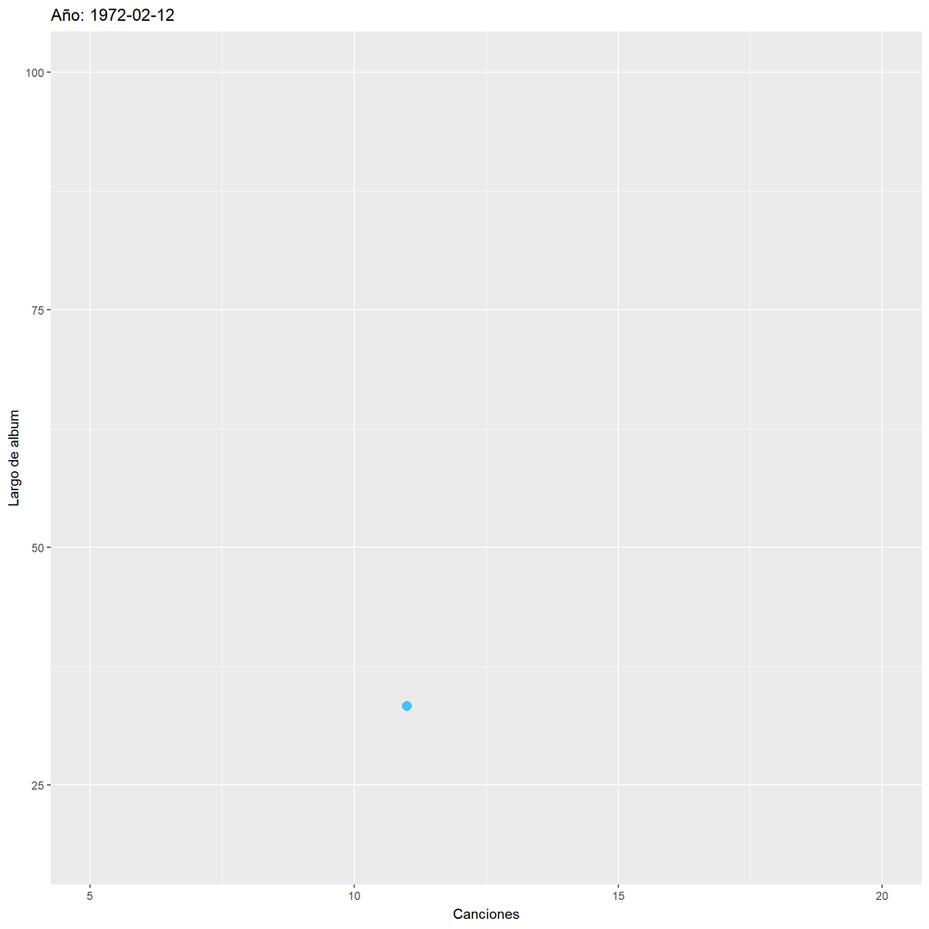

## Algunas conclusiones finales.

1. Charly García grabó más canciones solistas que en grupo.
2. Las canciones por disco varían entre 5 y 20, con una media de 12.84 en los 45 discos.
3. La discográfica que ha sacado mas canciones es Columbia, seguida de cerca por Universal. Gran parte de estas publicaciones se corresponden con su trabajo como solista.
4. Respecto de las song features generadas por Spotify, se observa que existe correlación lineal positiva entre: “energía” y “volúmen”, “bailabilidad” y “nivel de positividad”, “energía” y “nivel de positividad” y correlación negativa entre: “energía” y “acusticidad”. La popularidad, variable agregada al dataset original no estaría correlacionada linealmente con los otros indicadores.
5. De las features estudiadas, la relación entre “energía” y “volúmen” pareciera ajustar apropiadamente con un modelo LOESS, de grado 1 y alfa=0.6.
6. En sus origenes, Charly Garcia, participando en bandas como Seru Giran y Sui Generis, lanzaba temas de mayor acusticidad, y desde el Inamu (Ente Estatal). Luego se lanzó como solista y empezó a trabajar con discográficas multinacionales como Columbia y Universal. Produciendo temas con mayores niveles de energía. Columbia es el único sello discográfico con lanzamientos en las cinco décadas analizadas en este trabajo.
7. Respecto de los artistas relacionados (siempre de acuerdo al algoritmo o recomendación de Spotify) se observan similitudes en los comportamientos de los song features entre las canciones top de Charly y las top de los artistas relacionados.Las canciones más populares de Charly se diferencian del resto de la discografía, con niveles mayores de “energía”, “bailabilidad” y “alegría”. De aqui podría inferirse que aquellas canciones con valores altos en estas variables tienen mayores posibilidades de ser populares.
8. En 2000 y 2009 se lanzaron casi el 40% de las canciones presentes en Spotify de la década del 2000. Con 3 discos reediciones de Sui Generis, 2 discos especiales de Seru Giran y 2 especiales de Charly.
9. En cuanto al estilo de composición musical a lo largo de las 5 décadas analizadas, podría decirse que no se ha mantenido estable, con canciones que han modificado sus “Song Features” de la siguiente manera:

   *- más “bailables”.*

   *- con mayor nivel de “energía”.*

   *- con menor nivel de “acusticidad”*

   *- más equilibradas en “nivel de alegría”, en los 70s se observa una moda de canciones con menor “nivel de alegría”. Luego se va atenuenando la curva, lo que implica que hay mayor equilibrio entre canciones con distinto “nivel de alegría”.*

   *- con indice de popularidad tendiente a 20 a partir de la década del 80.*

   *- con una marcada tendencia a disminuir el nivel de “instrumentalidad”.*

9.La palabra más utilizada en los títulos de las Canciones de Charly es **“amor”**. 10. Respecto de las canciones grabadas en Estudio/Vivo se verifica que la variable liveness de Spotify crece conforme la canción tiene mayor probabilidad de haber sido grabada en Vivo. También se destaca que las canciones grabadas en vivo de Charly son menos Bailables que las versiones en estudio y menos populares. Mientras que las versiones de estudio tienen mayor instrumentalidad y nivel de alegría. 12. En cuanto a la duración de las canciones y discos con el paso de los años, aumentó la duración de los discos debido a la compilación de mayor cantidad de canciones. Posiblemente por la presencia de discos reeditados. En cambio no se identificaron variaciones en el largo de las canciones a lo largo del tiempo, de hecho pareciera existir un equilibrio en la cantidad de canciones “cortas”, “medias” y “largas” editadas por cada discográfica, como si existiera un modelo comercial estudiado sobre cómo debe estar compuesto un disco.